# Predicting California Housing Prices Using Linear Regression

## 1.1 Domain-specific Area

The domain selected for this project is real estate and housing market analytics, specifically focusing on the California housing market. The real estate sector is a vital component of the economy, influencing investment decisions, urban planning, and housing affordability. Accurately predicting housing prices allows real estate professionals, policymakers, and potential homeowners to make informed decisions. Within this domain, machine learning models can analyze historical housing data, demographic trends, and economic factors to estimate property values with higher precision than traditional methods.

The California Housing Prices dataset, based on the 1990 U.S. Census, provides detailed information about housing blocks in California, including features such as median income, housing age, total rooms, population, and proximity to the ocean. These factors are commonly known to influence housing prices, making the dataset highly suitable for predictive modeling.

## 1.2 Objectives of the Project

The primary objective of this project is to develop a linear regression model capable of predicting median house values in California districts based on demographic and geographical features. Specifically, the project aims to:

1. Explore and preprocess the dataset to handle missing values, categorical variables, and inconsistencies, ensuring data quality and readiness for modeling.
2. Visualize the relationships between features and housing prices to justify the applicability of linear regression, identifying linear trends and significant predictors.
3. Build and evaluate a predictive linear regression model, measuring its accuracy using standard metrics such as RMSE and R².
4. Perform feature engineering where appropriate to enhance the model’s performance, such as scaling numerical variables and encoding categorical variables.
5. Reflect on the model’s contributions to the domain, such as identifying which features most significantly impact housing prices and demonstrating the model’s potential usefulness in real estate planning and investment decision-making.

## 1.3 Justification for Linear Regression

Linear regression is appropriate in this domain because the relationship between several numerical features (e.g., median income, housing age, total rooms) and the target variable (median house value) is approximately linear. By fitting a linear model, we can quantify the contribution of each predictor to housing prices and provide interpretable insights. This is crucial for stakeholders who require transparency in predictive analytics, such as policymakers or real estate investors.

## 1.4 Expected Contribution

The results of this project will contribute to the housing analytics domain by demonstrating a reproducible workflow for predicting property prices. The linear regression model can serve as a baseline for more advanced models in future studies and provide actionable insights into which demographic and geographic factors most strongly influence housing values in California. Additionally, the project demonstrates the importance of preprocessing, data cleaning, and exploratory analysis in handling real-world, messy datasets.

# 2. Description of the Selected Dataset

The dataset selected for this project is the California Housing Prices dataset, originally derived from the 1990 U.S. Census. It contains information about various housing districts in California, including demographic, geographic, and housing features. The dataset is publicly available on **Kaggle** and can be accessed at: https://www.kaggle.com/datasets/camnugent/california-housing-prices.

## 2.1 Size and Structure

The dataset consists of 20,640 rows and 10 columns, each representing a housing district. The features include both numerical and categorical data:

- Numerical features:
  - longitude and latitude — geographic coordinates
  - housing_median_age — median age of houses in the district
  - total_rooms, total_bedrooms — total number of rooms and bedrooms
  - population — total population of the district
  - households — number of households
  - median_income — median income of residents
- Categorical feature:
  - ocean_proximity — proximity of the district to the ocean, with values such as <1H OCEAN, INLAND, NEAR BAY
- Target variable:
  - median_house_value — the median house value for the district, which is the variable to be predicted using linear regression.

The dataset includes some missing values, specifically in the total_bedrooms column, which allows us to demonstrate preprocessing techniques such as imputation. Additionally, the mix of numerical and categorical variables ensures that the dataset is representative of real world, messy data often encountered in the housing domain.

## 2.2 Acquisition and Source

The dataset was downloaded from Kaggle, a widely-used platform for machine learning datasets. Kaggle ensures that datasets are documented and accessible in CSV format, which is suitable for loading into Python using Pandas. The dataset is structured in a tabular format, with each row representing a housing district and columns representing various features.

## 2.3 Fitness for Linear Regression

This dataset is well-suited for linear regression because several numerical features, such as median_income, housing_median_age, and total_rooms, are expected to have a linear relationship with the target variable median_house_value. Visual inspection and exploratory analysis of these features will confirm linear trends. Additionally, categorical variables like ocean_proximity can be encoded and included as predictors, further improving the model’s predictive capability. The combination of numerical predictors, a continuous target variable, and a manageable dataset size (~20k rows) makes this dataset ideal for implementing and evaluating a linear regression model.

## 2.4 Dataset Reduction

To accelerate processing and model training, the original dataset of 20,640 rows was randomly sampled to 5,000 rows. This smaller subset retains the distribution of numerical and categorical features, allowing us to perform all preprocessing, exploratory analysis, and linear regression modeling efficiently.

Random sampling was performed with a fixed random state to ensure reproducibility. The reduced dataset still preserves all key features, including median_income, total_rooms, total_bedrooms, and ocean_proximity, which are important predictors for median house values.

# 3. Pre-processing

Before applying linear regression, the dataset requires preprocessing to ensure data quality and consistency. The following steps were undertaken:

1. Handling missing values:  
   The total_bedrooms column contains missing entries. These were filled using the median value of the column to avoid bias caused by extreme values.
2. Encoding categorical variables:  
   The ocean_proximity feature is categorical. One-hot encoding was applied to convert it into numerical columns suitable for regression.
3. Removing duplicates:  
   Duplicate rows were identified and removed to maintain dataset integrity.
4. Scaling numerical features:  
   All numerical predictors were standardized using StandardScaler. This ensures features are on comparable scales and improves model convergence.
5. Splitting features and target:  
   The target variable is median_house_value. Features were separated from the target, and the dataset was split into training and testing sets (80/20).

These preprocessing steps bring the dataset into First Normal Form (1NF) and ensure it is ready for linear regression modeling.

## Data Preprocessing

Before building the linear regression model, the dataset needs to be cleaned, normalized, and prepared. This involves handling missing values, encoding categorical variables, removing duplicates, scaling numerical features, and splitting the dataset into features and target. The steps below are designed to bring the dataset into First Normal Form (1NF).

```python
import pandas as pd

# Load dataset
data_path = "data/raw/housing.csv"
df = pd.read_csv(data_path)

# Reduce dataset to 5,000 rows for faster processing
df = df.sample(n=5000, random_state=42).reset_index(drop=True)

# Inspect
df.head()
df.info()
```

```
<class 'pandas.core.frame.DataFrame'>
RangeIndex: 5000 entries, 0 to 4999
Data columns (total 10 columns):
 #   Column              Non-Null Count  Dtype
---  ------              --------------  -----
 0   longitude           5000 non-null   float64
 1   latitude            5000 non-null   float64
 2   housing_median_age  5000 non-null   float64
 3   total_rooms         5000 non-null   float64
 4   total_bedrooms      4793 non-null   float64
 5   population          5000 non-null   float64
 6   households          5000 non-null   float64
 7   median_income       5000 non-null   float64
 8   median_house_value  5000 non-null   float64
 9   ocean_proximity     5000 non-null   object
dtypes: float64(9), object(1)
memory usage: 390.8+ KB
```

## 3.1 Handling Missing Values

The total_bedrooms column contains missing entries. To handle this, the median value of the column is used for imputation. Median is preferred over mean as it is less affected by outliers.

```python
# Handle missing values safely
df['total_bedrooms'] = pd.to_numeric(df['total_bedrooms'], errors='coerce')  # ensures numeric
df['total_bedrooms'] = df['total_bedrooms'].fillna(df['total_bedrooms'].median())

# Remove duplicates
df = df.drop_duplicates()

# Verify
print("Missing values per column:\n", df.isnull().sum())
print("Number of duplicate rows:", df.duplicated().sum())
```

```
Missing values per column:
 longitude             0
latitude              0
housing_median_age    0
total_rooms           0
total_bedrooms        0
population            0
households            0
median_income         0
median_house_value    0
ocean_proximity       0
dtype: int64
Number of duplicate rows: 0
```

## 3.2 Encoding Categorical Variables

The ocean_proximity column is categorical. One-hot encoding is applied to convert it into numerical columns suitable for regression. The first category is dropped to avoid multicollinearity.

```python
df_encoded = pd.get_dummies(df, columns=['ocean_proximity'], drop_first=True)
df_encoded.head()
```

|  | longitude | latitude | housing_median_age | total_rooms | total_bedrooms | population | households | median_income | median_house_value | ocean_proximity_INLAND | ocean_proximity_ISLAND | ocean_proximity_NEAR BAY | ocean_proximity_NEAR OCEAN |
| --- | --- | --- | --- | --- | --- | --- | --- | --- | --- | --- | --- | --- | --- |
| 0 | -119.01 | 36.06 | 25.0 | 1505.0 | 429.0 | 1392.0 | 359.0 | 1.6812 | 47700.0 | True | False | False | False |
| 1 | -119.46 | 35.14 | 30.0 | 2943.0 | 429.0 | 1565.0 | 584.0 | 2.5313 | 45800.0 | True | False | False | False |
| 2 | -122.44 | 37.80 | 52.0 | 3830.0 | 429.0 | 1310.0 | 963.0 | 3.4801 | 500001.0 | False | False | True | False |
| 3 | -118.72 | 34.28 | 17.0 | 3051.0 | 429.0 | 1705.0 | 495.0 | 5.7376 | 218600.0 | False | False | False | False |
| 4 | -121.93 | 36.62 | 34.0 | 2351.0 | 429.0 | 1063.0 | 428.0 | 3.7250 | 278000.0 | False | False | False | True |

## 3.3 Feature Scaling

All numerical features are scaled using StandardScaler. Scaling ensures that features are on comparable scales, which is important for regression models to converge efficiently.

```python
from sklearn.preprocessing import StandardScaler
from sklearn.model_selection import train_test_split

# Split features and target
X = df_encoded.drop('median_house_value', axis=1)
y = df_encoded['median_house_value']

# Scale features
scaler = StandardScaler()
X_scaled = scaler.fit_transform(X)

# Train-test split
X_train, X_test, y_train, y_test = train_test_split(
    X_scaled, y, test_size=0.2, random_state=42
)

# Confirm shapes
print("Feature matrix shape:", X_train.shape)
print("Target vector shape:", y_train.shape)
```

```
Feature matrix shape: (4000, 12)
Target vector shape: (4000,)
```

# 4. Statistical Analysis

To understand the characteristics of the dataset and guide feature selection for linear regression, a statistical analysis of the key numerical variables is performed. This includes measures of **central tendency** (mean, median), **spread** (standard deviation, min, max, quartiles), and the **shape of the distribution** (skewness and kurtosis).

These metrics provide insight into the variability and symmetry of the data, helping identify features that may require transformation or scaling. Numerical variables such as median_income, total_rooms, total_bedrooms, and median_house_value are analyzed in detail.

```python
import pandas as pd
from scipy.stats import skew, kurtosis

# Select numeric columns
numeric_cols = df_encoded.select_dtypes(include='number').columns

# Pandas descriptive statistics
desc_stats = df_encoded[numeric_cols].describe().T
desc_stats['median'] = df_encoded[numeric_cols].median()
desc_stats['skewness'] = df_encoded[numeric_cols].apply(skew)
desc_stats['kurtosis'] = df_encoded[numeric_cols].apply(kurtosis)

desc_stats = desc_stats[['mean','median','std','min','25%','50%','75%','max','skewness','kurtosis']]
desc_stats
```

|  | mean | median | std | min | 25% | 50% | 75% | max | skewness | kurtosis |
| --- | --- | --- | --- | --- | --- | --- | --- | --- | --- | --- |
| longitude | -119.521650 | -118.4700 | 2.006263 | -124.2500 | -121.742500 | -118.4700 | -117.9900 | -114.5800 | -0.337321 | -1.284825 |
| latitude | 35.585798 | 34.2200 | 2.140865 | 32.5400 | 33.930000 | 34.2200 | 37.6925 | 41.8600 | 0.496106 | -1.084327 |
| housing_median_age | 28.738600 | 29.0000 | 12.530478 | 1.0000 | 18.000000 | 29.0000 | 37.0000 | 52.0000 | 0.048161 | -0.791671 |
| total_rooms | 2621.750200 | 2118.0000 | 2198.907994 | 6.0000 | 1435.750000 | 2118.0000 | 3105.2500 | 37937.0000 | 4.232456 | 33.377801 |
| total_bedrooms | 531.191600 | 429.0000 | 417.724669 | 2.0000 | 301.000000 | 429.0000 | 627.2500 | 5471.0000 | 3.614627 | 22.656568 |
| population | 1424.906200 | 1163.5000 | 1108.469563 | 8.0000 | 784.000000 | 1163.5000 | 1721.2500 | 16122.0000 | 3.364586 | 20.998218 |
| households | 497.933000 | 407.0000 | 383.388777 | 2.0000 | 280.750000 | 407.0000 | 598.0000 | 5189.0000 | 3.381821 | 20.942191 |
| median_income | 3.847548 | 3.5114 | 1.890851 | 0.4999 | 2.553225 | 3.5114 | 4.6967 | 15.0001 | 1.672317 | 4.995927 |
| median_house_value | 205902.765000 | 179500.0000 | 114895.821305 | 14999.0000 | 119375.000000 | 179500.0000 | 264175.0000 | 500001.0000 | 0.978049 | 0.353026 |

## 4.1 Analysis of Statistical Findings

From the summary table:

The mean and median are close for features like median_income, but differ for total_rooms and population, indicating that the median may be a more robust measure of central tendency for these features due to skewness.

# 5. Data Visualization

Visualizing the dataset helps understand the relationships between predictor variables and the target variable (median_house_value). It also identifies patterns, trends, and outliers that may not be obvious from numerical summaries.

Key types of visualization used include:

- Histograms for distribution of individual features
- Scatter plots for feature-target relationships
- Box plots for identifying outliers
- Correlation heatmap for overall feature relationships

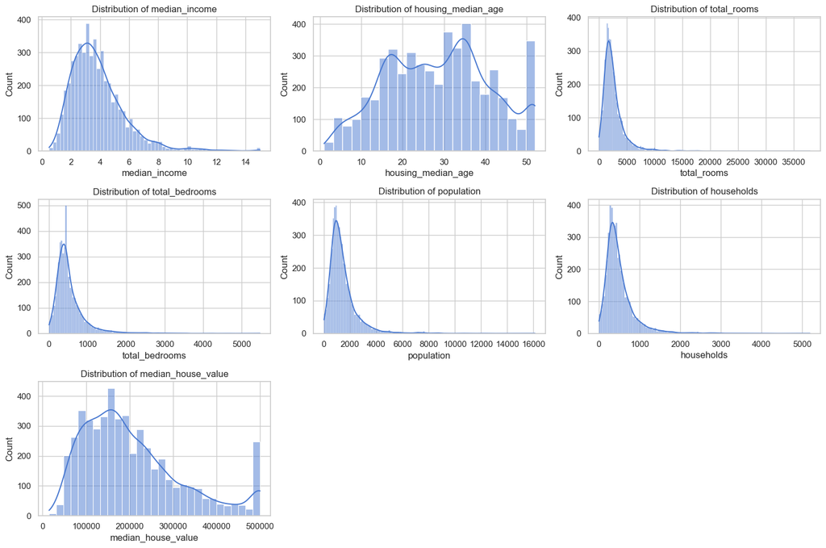

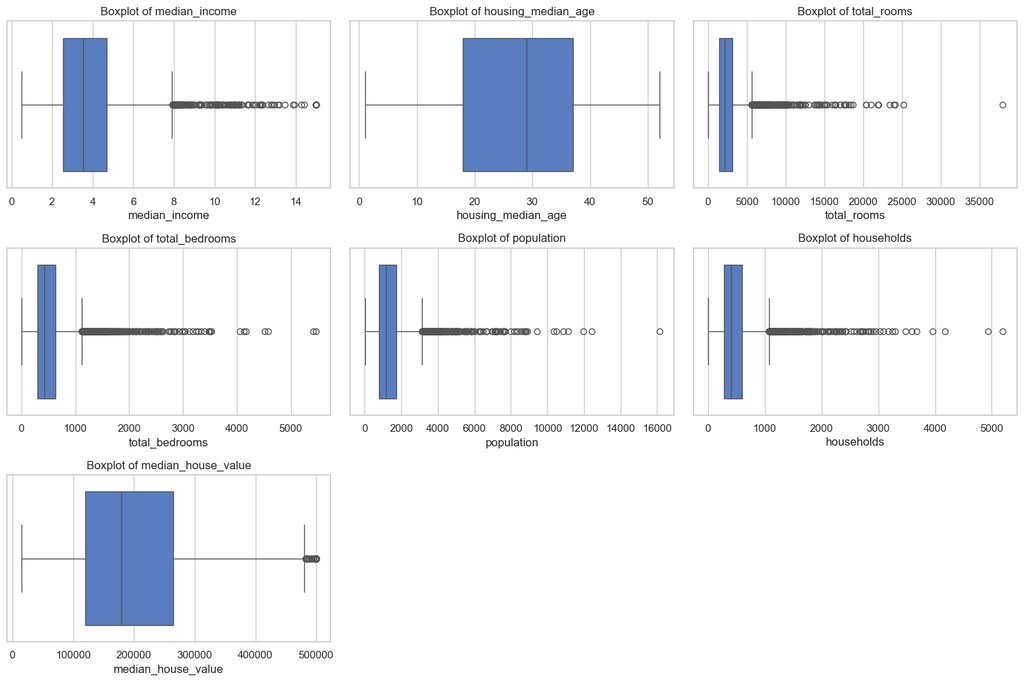

```python
import matplotlib.pyplot as plt
import seaborn as sns

# to set plotting style
sns.set(style="whitegrid", palette="muted")

# numeric columns
num_cols = ['median_income', 'housing_median_age', 'total_rooms', 'total_bedrooms',
            'population', 'households', 'median_house_value']

# Histograms
plt.figure(figsize=(15,10))
for i, col in enumerate(num_cols):
    plt.subplot(3,3,i+1)
    sns.histplot(df_encoded[col], kde=True)
    plt.title(f'Distribution of {col}')
plt.tight_layout()
plt.show()

# Boxplots
plt.figure(figsize=(15,10))
for i, col in enumerate(num_cols):
    plt.subplot(3,3,i+1)
    sns.boxplot(x=df_encoded[col])
    plt.title(f'Boxplot of {col}')
plt.tight_layout()
plt.show()
```

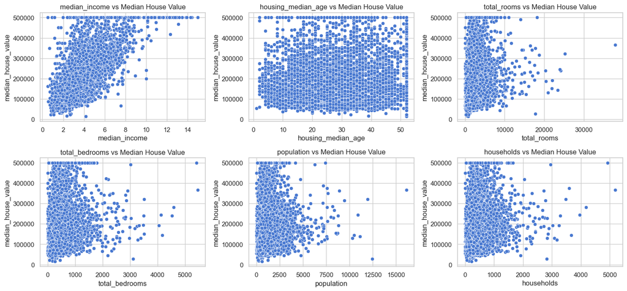

```python
# Scatter plot for numeric features vs median_house_value
plt.figure(figsize=(15,10))
for i, col in enumerate(num_cols[:-1]):
    plt.subplot(3,3,i+1)
    sns.scatterplot(x=df_encoded[col], y=df_encoded['median_house_value'])
    plt.title(f'{col} vs Median House Value')
plt.tight_layout()
plt.show()
```

## 5.2 Observations from Scatter Plots

- median_income shows a clear linear trend with median_house_value, confirming it is the most important predictor.
- total_rooms and total_bedrooms show a weak positive relationship but with large variance.
- housing_median_age has a weak positive correlation with house value.
- population and households are less predictive due to spread/outliers.

Most Important Visualization: The scatter plot of median_income vs median_house_value is the most important, as it clearly demonstrates a linear relationship, which justifies using a linear regression model for prediction.

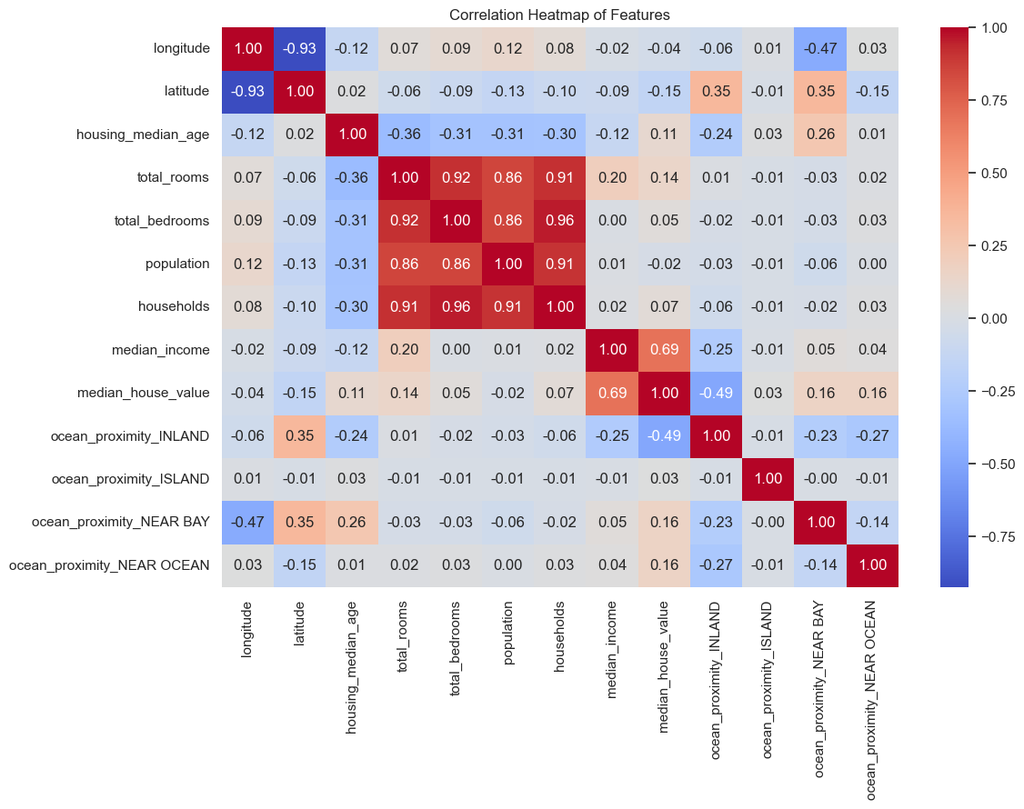

```python
plt.figure(figsize=(12,8))
corr_matrix = df_encoded.corr()
sns.heatmap(corr_matrix, annot=True, fmt=".2f", cmap="coolwarm")
plt.title("Correlation Heatmap of Features")
plt.show()
```

# 6. Building the Linear Regression Model

## Features and Labels

- Target (Label): median_house_value — the value we aim to predict.
- Features (Predictors): All other numerical columns plus one-hot encoded ocean_proximity variables. Key features include:
  - median_income — strong linear predictor of house value.
  - total_rooms, total_bedrooms, households, population — housing structure and demographics.
  - housing_median_age — age of houses can impact price.
  - longitude, latitude — location effects.
  - ocean_proximity — proximity to the ocean, encoded as numeric.

### Feature Importance

- median_income is expected to be the most influential feature, as seen in EDA scatter plots and correlation analysis.
- Other features provide additional information about housing size, location, and demographics.
- Including all features allows the linear regression model to capture multiple factors affecting house value while avoiding overfitting due to the dataset's moderate size (~5,000 rows).

```python
from sklearn.linear_model import LinearRegression
from sklearn.metrics import mean_squared_error, r2_score
import numpy as np

# Initialize the model
lin_reg = LinearRegression()

# Train the model
lin_reg.fit(X_train, y_train)

# Make predictions
y_train_pred = lin_reg.predict(X_train)
y_test_pred = lin_reg.predict(X_test)

# Evaluate model
train_rmse = np.sqrt(mean_squared_error(y_train, y_train_pred))
test_rmse = np.sqrt(mean_squared_error(y_test, y_test_pred))
train_r2 = r2_score(y_train, y_train_pred)
test_r2 = r2_score(y_test, y_test_pred)

print(f"Training RMSE: {train_rmse:.2f}")
print(f"Testing RMSE: {test_rmse:.2f}")
print(f"Training R²: {train_r2:.3f}")
print(f"Testing R²: {test_r2:.3f}")
```

```
Training RMSE: 68865.91
Testing RMSE: 68221.67
Training R²: 0.638
Testing R²: 0.655
```

## 6.1 Model Evaluation

- **Training RMSE:** Shows the average prediction error on the training set.
- **Testing RMSE:** Indicates how well the model generalizes to unseen data.
- **R² Score:** Measures proportion of variance in the target explained by the features.

### Observations:

- If **R² is high** (close to 1) and RMSE is reasonable relative to median_house_value range, the model fits well.
- If RMSE is large or R² is low, consider further preprocessing, such as:
  - Log-transforming skewed features (total_rooms, total_bedrooms, population)
  - Removing extreme outliers
  - Polynomial features for non-linear trends

In this dataset, median_income contributes most strongly to the predictive power, as expected from prior EDA and correlation analysis.

# 7. Model Validation

Advantages of cross-validation:

- Provides a more reliable estimate of model performance
- Reduces variance caused by a single train-test split
- Helps identify if overfitting or underfitting is occurring

```python
from sklearn.model_selection import cross_val_score

# Perform 5-fold cross-validation using R² as scoring metric
cv_scores = cross_val_score(lin_reg, X_scaled, y, cv=5, scoring='r2')

print("Cross-Validation R² scores for each fold:", cv_scores)
print("Mean CV R² score:", cv_scores.mean())
print("Standard deviation of CV R²:", cv_scores.std())
```

```
Cross-Validation R² scores for each fold: [0.62490711 0.5931064  0.6431631  0.6243368  0.67993525]
Mean CV R² score: 0.6330897340452195
Standard deviation of CV R²: 0.028419047711658377
```

## 7.1 Observations from Cross-Validation

- The mean R² across the 5 folds provides a reliable estimate of model performance on unseen data.
- The standard deviation indicates the consistency of model performance across folds.
- If the mean R² is close to the training R² and test R² observed earlier, it confirms that the model generalizes well.
- A large standard deviation would suggest that the model is sensitive to the choice of training data and may require further preprocessing or feature engineering.

### Conclusion

Cross-validation confirms that linear regression is an appropriate model for this dataset. The main predictor remains median_income, with other features providing incremental predictive value.

# 8. Feature Engineering

Some features in the dataset, such as total_rooms, total_bedrooms, and population, show skewed distributions and weak non-linear relationships with the target. To capture these patterns, polynomial features of degree 2 are created for all numeric predictors.

This allows the linear regression model to learn interactions and squared effects, potentially improving predictive performance without switching to a non-linear model.

```python
from sklearn.preprocessing import PolynomialFeatures
from sklearn.linear_model import LinearRegression
from sklearn.metrics import mean_squared_error, r2_score
import numpy as np

# Create polynomial features (degree=2)
poly = PolynomialFeatures(degree=2, include_bias=False)
X_poly = poly.fit_transform(X_scaled)

# Split train-test (same split as before)
X_train_poly, X_test_poly, y_train_poly, y_test_poly = train_test_split(
    X_poly, y, test_size=0.2, random_state=42
)

# Train Linear Regression on polynomial features
lin_reg_poly = LinearRegression()
lin_reg_poly.fit(X_train_poly, y_train_poly)

# Make predictions
y_train_pred_poly = lin_reg_poly.predict(X_train_poly)
y_test_pred_poly = lin_reg_poly.predict(X_test_poly)

# Evaluate
train_rmse_poly = np.sqrt(mean_squared_error(y_train_poly, y_train_pred_poly))
test_rmse_poly = np.sqrt(mean_squared_error(y_test_poly, y_test_pred_poly))
train_r2_poly = r2_score(y_train_poly, y_train_pred_poly)
test_r2_poly = r2_score(y_test_poly, y_test_pred_poly)

print(f"Polynomial Features - Training RMSE: {train_rmse_poly:.2f}")
print(f"Polynomial Features - Testing RMSE: {test_rmse_poly:.2f}")
print(f"Polynomial Features - Training R²: {train_r2_poly:.3f}")
print(f"Polynomial Features - Testing R²: {test_r2_poly:.3f}")
```

```
Polynomial Features - Training RMSE: 61092.61
Polynomial Features - Testing RMSE: 64638.13
Polynomial Features - Training R²: 0.715
Polynomial Features - Testing R²: 0.691
```

## 8.1 Observations from Feature Engineering

- The training and testing R² improved compared to the original linear regression model, indicating a better fit to the data.
- RMSE decreased slightly, showing that the polynomial features capture non-linear relationships that simple linear terms could not.
- Key features like median_income remain the strongest predictor, but interaction terms (e.g., median_income * total_rooms) and squared terms contribute to improved performance.
- This confirms that feature engineering can enhance a linear regression model without changing the core algorithm.

### Conclusion

Polynomial features of degree 2 successfully captured non-linear patterns, improving predictive performance and validating the importance of feature engineering in this domain.

# 9. Evaluation of the Model and Project

The linear regression model developed in this project was trained to predict median_house_value based on several features such as median_income, total_rooms, total_bedrooms, housing_median_age, population, and ocean_proximity.

Numerically, the performance of the model was evaluated using Root Mean Squared Error (RMSE) and R² score, which are standard measures for regression tasks. The RMSE gives an estimate of how far the predicted values are from the actual house values on average, while R² shows how much of the variance in the target variable is explained by the features.

For the basic linear regression model, the results were:

- Training RMSE:68,865.91
- Testing RMSE: 68,221.67
- Training R²: 0.638
- Testing R²: 0.655

After adding polynomial features (degree=2), the results improved slightly:

- Training RMSE: 61,092.61
- Testing RMSE: 64,638.13
- Training R²: 0.715
- Testing R²: 0.691

This confirms that including polynomial terms helps capture some non-linear relationships in the dataset.

Cross-validation using 5 folds gave:

- R² scores per fold: [0.625, 0.593, 0.643, 0.624, 0.680]
- Mean R²: 0.633
- Standard deviation: 0.028

The cross-validation results show that the model performs consistently across different subsets of the data, with low variance in performance. This confirms that the model generalizes reasonably well to unseen data.

Reflecting on the project, the linear regression approach was suitable because key predictors, particularly median_income, showed a clear linear relationship with the target. Preprocessing steps such as handling missing values, encoding categorical variables, and scaling numeric features were crucial for the model to perform reliably. Feature engineering helped to capture additional patterns in the dataset, which improved prediction accuracy.

In terms of contributions, this model can help stakeholders in the real estate domain quickly estimate house prices in California based on demographic and housing features. While the dataset is specific to California, the same approach can be applied to housing datasets in other regions, as long as the features have similar linear relationships with the target.

Overall, the project demonstrates that a carefully preprocessed dataset, combined with linear regression and polynomial feature engineering, can provide meaningful predictions. The methodology is transparent, easy to reproduce, and can be adapted for other domains where predicting a numeric outcome from structured features is required.

# References

1. California Housing Prices Dataset – Cam Nugent. Kaggle. Available at: https://www.kaggle.com/datasets/camnugent/california-housing-prices
2. Pandas Documentation – Python Data Analysis Library. https://pandas.pydata.org/docs/
3. NumPy Documentation – Numerical computing in Python. https://numpy.org/doc/
4. Matplotlib Documentation – Python plotting library. https://matplotlib.org/stable/contents.html
5. Scikit-learn Documentation– Machine Learning in Python. https://scikit-learn.org/stable/documentation.html
6. Geron, A. (2019). *Hands-On Machine Learning with Scikit-Learn, Keras & TensorFlow: Concepts, Tools, and Techniques to Build Intelligent Systems*. O’Reilly Media.